# Homework - Week 5 Day 1

Load libraries

```r
library(tidyverse)
library(CodeClanData)
```

**Question 1.**

Load in the libraries you need, and look at the `backpack` data. Take note of variable names and dimensions.

```r
glimpse(backpack)
```

```
Rows: 100
Columns: 9
$ backpack_weight <int> 9, 8, 10, 6, 8, 5, 8, 4, 5, 2, 8, 21, 11, 11, 12, 11, 13, 6, 10, 5, 20…
$ body_weight     <int> 125, 195, 120, 155, 180, 240, 170, 185, 130, 120, 135, 160, 170, 170, …
$ ratio           <dbl> 0.0720000, 0.0410256, 0.0833333, 0.0387097, 0.0444444, 0.0208333, 0.04…
$ back_problems   <int> 1, 0, 1, 0, 0, 0, 0, 1, 0, 0, 0, 0, 0, 1, 1, 0, 1, 0, 1, 0, 0, 1, 0, 0…
$ major           <fct> Bio, Philosophy, GRC, CSC, EE, History, CM, ARCE, Bio, Bio, Bus, ME, C…
$ year            <int> 3, 5, 4, 6, 2, 0, 3, 5, 4, 5, 3, 5, 4, 4, 3, 4, 4, 3, 3, 3, 2, 2, 5, 5…
$ sex             <fct> Female, Male, Female, Male, Female, Male, Male, Female, Female, Female…
$ status          <fct> U, U, U, G, U, G, U, U, U, U, U, U, U, U, U, U, U, U, U, U, U, U, U, U…
$ units           <int> 13, 12, 14, 0, 14, 0, 15, 18, 14, 8, 15, 12, 16, 16, 12, 16, 16, 16, 1…
```

**Question 2.**

The bar chart shows the count of backpacks by weight.

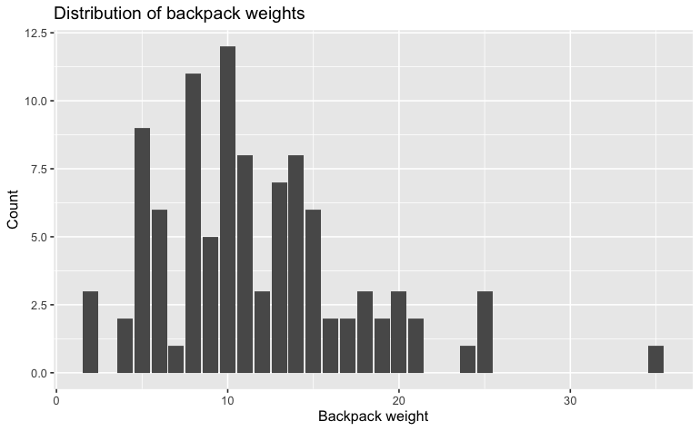

**Question 3.**

The plot below again shows the distribution of backpack weights, but this time shows the distribution for female/male separately.

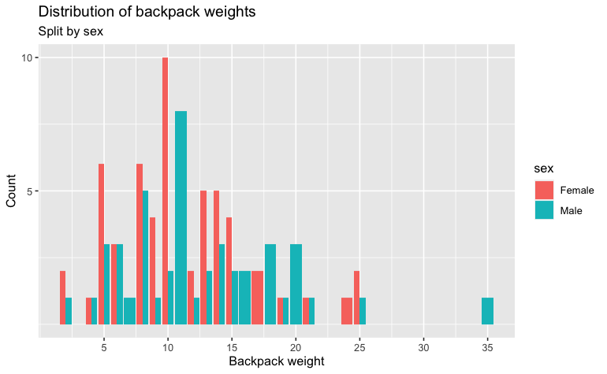

```r
backpack %>%
  ggplot() +
  aes(x = backpack_weight,
      group = sex,
      fill = sex) +
  geom_bar(position = "dodge") +
  labs(x = "Backpack weight",
       y = "Count",
       title = "Distribution of backpack weights",
       subtitle = "Split by sex"
       ) +
  scale_x_continuous(breaks = c(5,10,15,20,25,30,35)) +
  scale_y_continuous(breaks = c(5,10))
```

```r
  #facet_wrap(~sex)
```

**Question 4.**

The output below plots body weight (x axis) against backpack weight (y axis). A straight line fitted through the data shows a weak relationship, with backpack weight increasing with bodyweight

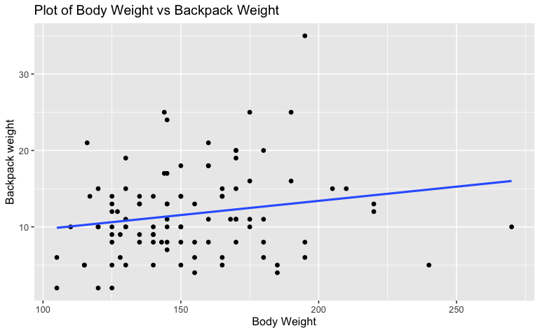

```r
backpack %>%
  ggplot() +
  aes(x = body_weight,
      y = backpack_weight) +
  geom_point() +
  geom_smooth(
    aes(x = body_weight,
        y = backpack_weight),
    method = "lm",
    se = FALSE
  ) +
  labs(x = "Body Weight",
       y = "Backpack weight",
       title = "Plot of Body Weight vs Backpack Weight")
```

**Question 5.**

The plot above is repeated, but this time split by female/male. The fitted line is steeper for females than males, suggesting backpack weight increases faster with bodyweight for females than males.

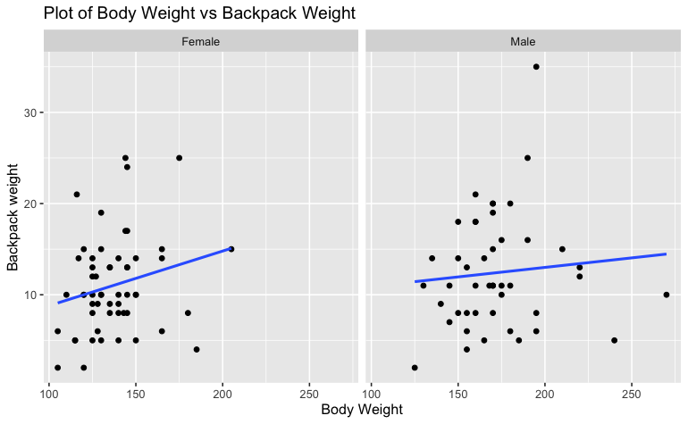

**Question 6.**

What **proportion** of students report back pain?

*** This isn’t correct as it is not the proportion.

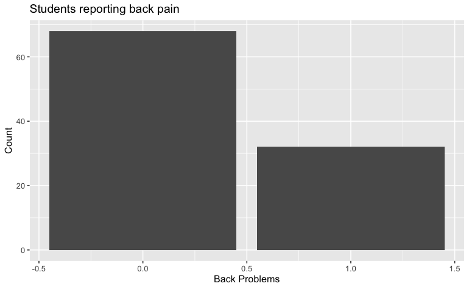

**Question 7.**

Is this proportion different between men and women?

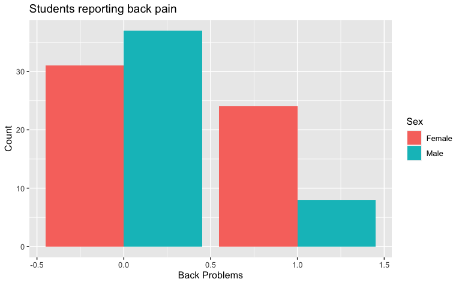

```r
backpack %>%
  ggplot() +
  aes(x = back_problems, fill = sex) +
  geom_bar(position = "dodge") +
  labs(x = "Back Problems",
       y = "Count",
       fill = "Sex",
       title = "Students reporting back pain")
```

```r
NA
NA
```

**Question 8.**

Now you’ve investigated your data separately, create plots to describe the relationship between backpack weight, body weight, gender and reported backpain.

Try both `backpack_weight` and `body_weight` as well as the `ratio`.

*Hint: faceting would be useful here*.

These plot the indicator “backpain” against (1) backpack_weight (2) body_weight and (3) ratio of backpack to body weight, split by sex.

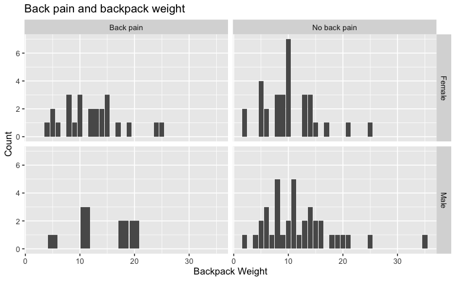

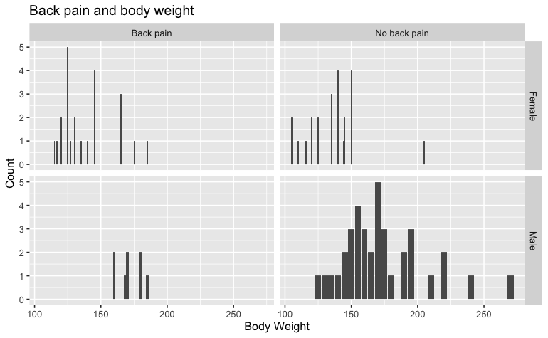

```r
backpack %>%
  mutate(backpain = ifelse(back_problems == 1, "Back pain", "No back pain")) %>%
  ggplot() +
  aes(x = body_weight) +
  geom_bar() +
  labs(x = "Body Weight",
       y = "Count",
       title = "Back pain and body weight") +
  facet_grid(sex ~ backpain)
```

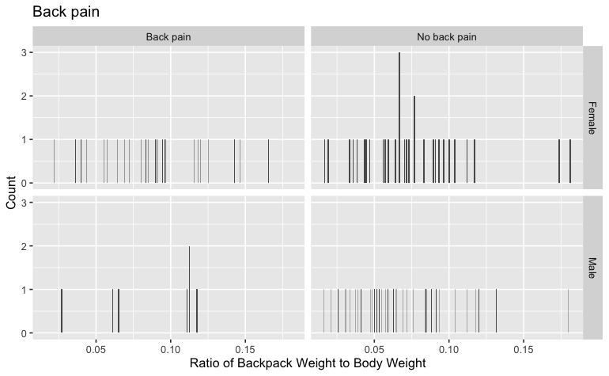

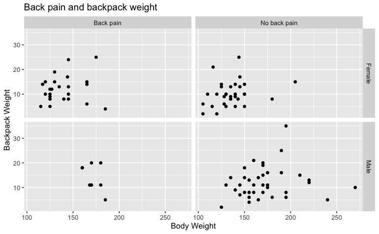

```r
backpack %>%
  mutate(backpain = ifelse(back_problems == 1, "Back pain", "No back pain")) %>%
  ggplot() +
  aes(x = body_weight,
    y = backpack_weight) +
  geom_point() +
  labs(x = "Body Weight",
       y = "Backpack Weight",
       title = "Back pain and backpack weight") +
  facet_grid(sex ~ backpain)
```

# Extensions

**Question 1.**

Does reported backpain differ across the year groups? Ignore year 0 in your data.

**Question 2.**

Is there a difference between how heavy the bags those in different years carry?